# Multiple Linear Regression Model

## Executive Summary

The team has developed a model using historical baseball data to determine a team’s performance based on statistics of their performance. While correlation does not equal causation it is suggested that a focus on some of the variables such as a focus on either single hits or triple or more hits to the exclusion of doubles might be worth pursuing. Also the data suggests that a focus on home runs allowed may not be worth giving up a number of more normal hits.

## Data Used

In this project, we are asked to explore, analyze and model a baseball dataset. Each record represents a particular professional baseball team from the years 1871 to 2006 inclusive. Each record has the performance of the given team for the given year, with all of the statistics adjusted as if the team were playing a 162 game season.

Our objective is to build a multiple linear regression model on the training data to predict the number of wins for the team, based on their other performance variables. This data set is split between a training dataset of 2276 observation for model development and a test dataset of 259 observations for model validation.

A short description of the variables and their theoretical effect on the response variable ‘Number of wins’ is provided.

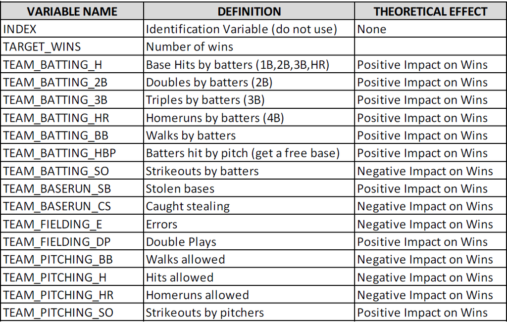

## Data exploration

Looking at the data it is clear that all of the data is numeric, and that Hit By Pitch has a lot of missing variables.

```
##   TARGET_WINS       BATTING_H      BATTING_2B      BATTING_3B
##  Min.   :  0.00   Min.   : 891   Min.   : 69.0   Min.   :  0.00
##  1st Qu.: 71.00   1st Qu.:1383   1st Qu.:208.0   1st Qu.: 34.00
##  Median : 82.00   Median :1454   Median :238.0   Median : 47.00
##  Mean   : 80.79   Mean   :1469   Mean   :241.2   Mean   : 55.25
##  3rd Qu.: 92.00   3rd Qu.:1537   3rd Qu.:273.0   3rd Qu.: 72.00
##  Max.   :146.00   Max.   :2554   Max.   :458.0   Max.   :223.00
##
##    BATTING_HR       BATTING_BB      BATTING_SO       BASERUN_SB
##  Min.   :  0.00   Min.   :  0.0   Min.   :   0.0   Min.   :  0.0
##  1st Qu.: 42.00   1st Qu.:451.0   1st Qu.: 548.0   1st Qu.: 66.0
##  Median :102.00   Median :512.0   Median : 750.0   Median :101.0
##  Mean   : 99.61   Mean   :501.6   Mean   : 735.6   Mean   :124.8
##  3rd Qu.:147.00   3rd Qu.:580.0   3rd Qu.: 930.0   3rd Qu.:156.0
##  Max.   :264.00   Max.   :878.0   Max.   :1399.0   Max.   :697.0
##                                   NA's   :102      NA's   :131
##    BASERUN_CS     BATTING_HBP      PITCHING_H     PITCHING_HR
##  Min.   :  0.0   Min.   :29.00   Min.   : 1137   Min.   :  0.0
##  1st Qu.: 38.0   1st Qu.:50.50   1st Qu.: 1419   1st Qu.: 50.0
##  Median : 49.0   Median :58.00   Median : 1518   Median :107.0
##  Mean   : 52.8   Mean   :59.36   Mean   : 1779   Mean   :105.7
##  3rd Qu.: 62.0   3rd Qu.:67.00   3rd Qu.: 1682   3rd Qu.:150.0
##  Max.   :201.0   Max.   :95.00   Max.   :30132   Max.   :343.0
##  NA's   :772     NA's   :2085
##   PITCHING_BB      PITCHING_SO        FIELDING_E      FIELDING_DP
##  Min.   :   0.0   Min.   :    0.0   Min.   :  65.0   Min.   : 52.0
##  1st Qu.: 476.0   1st Qu.:  615.0   1st Qu.: 127.0   1st Qu.:131.0
##  Median : 536.5   Median :  813.5   Median : 159.0   Median :149.0
##  Mean   : 553.0   Mean   :  817.7   Mean   : 246.5   Mean   :146.4
##  3rd Qu.: 611.0   3rd Qu.:  968.0   3rd Qu.: 249.2   3rd Qu.:164.0
##  Max.   :3645.0   Max.   :19278.0   Max.   :1898.0   Max.   :228.0
##                   NA's   :102                        NA's   :286
```

6 of the variables have missing values:

• BATTING_SO: 102 (4.5% of total)

• PITCHING_SO: 102 (4.5% of total)

• BASERUN_SB: 131 (5.8% of total)

• BASERUN_CS: 772 (34% of total, needs to be looked at closely, impute or exclude?)

• BATTING_HBP: 2085 (92% of total, exclude from analysis?)

• FIELDING_DP: 286 (12.6% of total,needs to be looked at closely, impute or exclude?)

The following diagram shows the missingness pattern by variables.

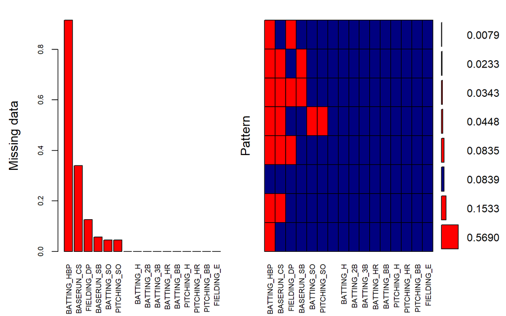

### Outliers

The following diagram shows the outliers for all the variables, both dependent and independent.

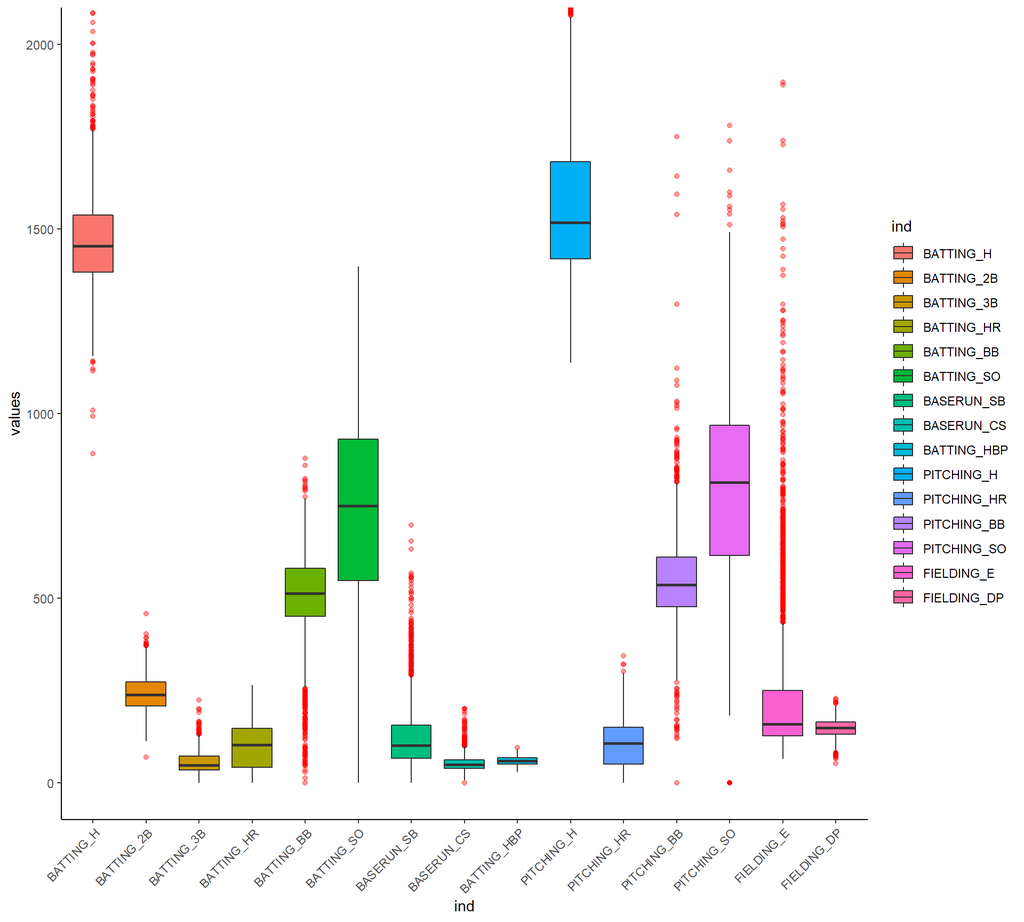

We can see that 12 of the variables have a significant skew. only 4 of the 16 variables are normally or close to normally distributed. The response variable Target_wins seems to be normally distributed. Batting_Hr, Batting_SO and Pitching_HR are bi-modal.

10 of the 16 variables have a minimum value of 0. This is not a major concern as the total % of 0 in each column is less than 1%.

The variables Batting_BB, Batting_CS, Baserun_SB, Pitching_BB and Fielding_E have a significant number of outliers.

### Correlations among predictors

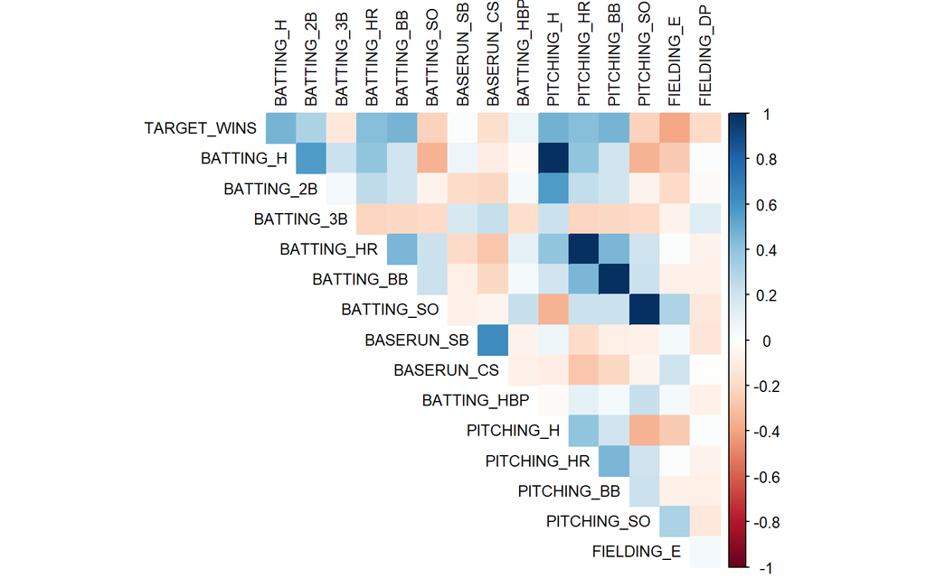

There are positive or negative correlations among the predictors. A small number of values are not correlated. Let us look at the numerical correlations with the response variable. We see that the predictors Batting_H, Batting_HR, Batting_BB, Pitching_H, and Pitching_HR are more correlated and should be included in our regression.

| rowname | Variable | Correlation |
| --- | --- | --- |
| TARGET_WINS | TARGET_WINS | 1.0000000 |
| PITCHING_H | TARGET_WINS | 0.4712343 |
| BATTING_H | TARGET_WINS | 0.4699467 |
| BATTING_BB | TARGET_WINS | 0.4686879 |
| PITCHING_BB | TARGET_WINS | 0.4683988 |
| PITCHING_HR | TARGET_WINS | 0.4224668 |
| BATTING_HR | TARGET_WINS | 0.4224168 |
| BATTING_2B | TARGET_WINS | 0.3129840 |
| BATTING_HBP | TARGET_WINS | 0.0735042 |
| BASERUN_SB | TARGET_WINS | 0.0148364 |
| BATTING_3B | TARGET_WINS | -0.1243459 |
| BASERUN_CS | TARGET_WINS | -0.1787560 |
| FIELDING_DP | TARGET_WINS | -0.1958660 |
| BATTING_SO | TARGET_WINS | -0.2288927 |
| PITCHING_SO | TARGET_WINS | -0.2293648 |
| FIELDING_E | TARGET_WINS | -0.3866880 |

| rowname | Variable | Correlation |
| --- | --- | --- |
| BATTING_2B | BATTING_H | 0.5617729 |
| PITCHING_H | BATTING_H | 0.9991927 |
| PITCHING_H | BATTING_2B | 0.5604535 |
| PITCHING_HR | BATTING_HR | 0.9999326 |
| PITCHING_BB | BATTING_BB | 0.9998814 |
| PITCHING_SO | BATTING_SO | 0.9997684 |
| BASERUN_CS | BASERUN_SB | 0.6247378 |

Examining significant correlations among the independent variables, we see that four of the pairs have a correlation close to 1. This can lead to multicollinearity issues in our analysis.

## Data Preparation

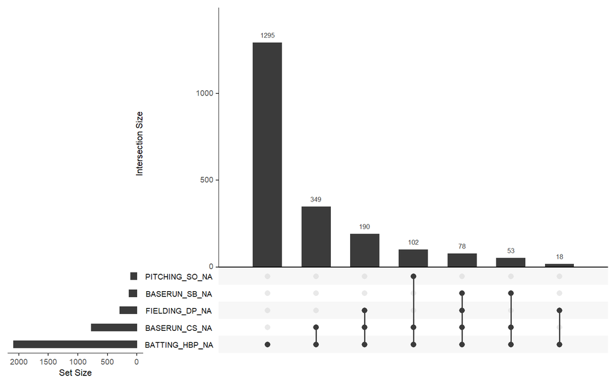

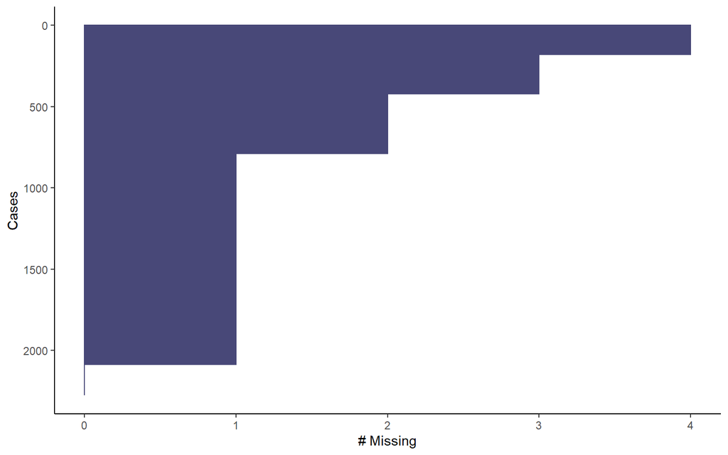

In deciding whether data is MCAR (Missing Completely At Random) or MAR, one approach is to explore patterns of missingness between variables. This is particularly important for a primary outcome measure/dependent variable. We will test the two cases with most missing values.

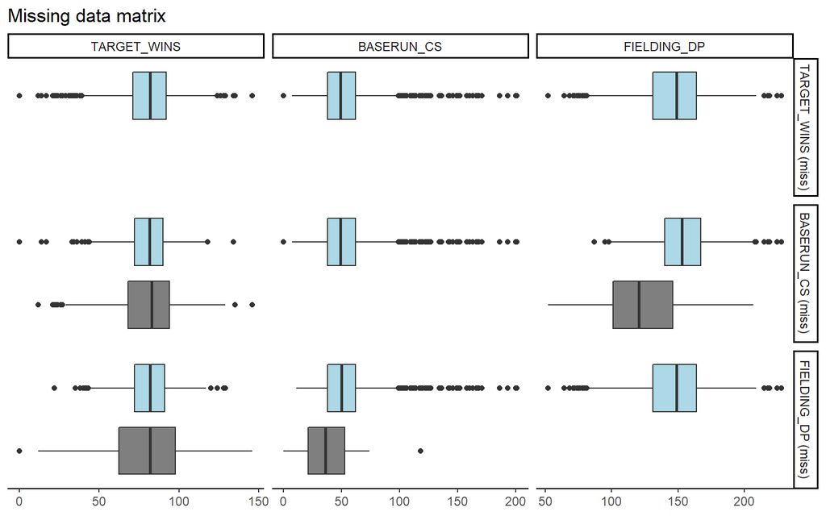

The wins for teams whose Caught Stealing (Baserun_cs) data is known is the blue box plot, and the wins with missing Baserun_cs data is the gray box plot. We do not see a lot of difference in the mean, but the Interquartile range has changed. Also the mean changes significantly between Double Play (Fielding_DP) and Baserun_cs if we do not include missing data.

102 of the observations have 3 of the variables missing.The highest case missing is in the BASERUN_CS variable, so this deserves an analysis of its own.We find a highly positively skewed distribution with most missing data after the 125 on the x axis. We want to make sure that the shape of our distribution does not change as we impute the data.

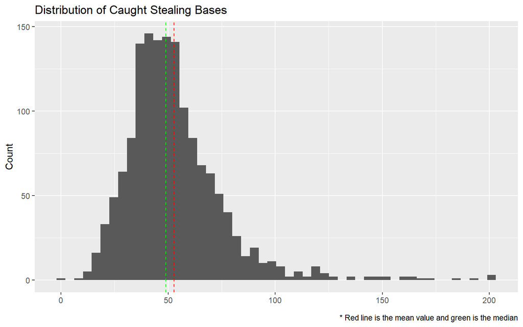

## Data Preparation for Modeling

### Model 1 - Basic Model

In this model, we replace the missing values for each column with their median.

All the missing values were replaced by the median of it’s column. Most of the variables don’t have extreme outliers but still it has some sort of skewness but we won’t remove them because it might change the model’s fitness. We will fix the model in next steps and check which model performs better. Variables like Hits Allowed and Walks by Batters are skewed significantly which we have to transform in next models.

### Model 2 - Log Transformation

Skewness is comparatively much better now as it was in previous model.

```
## TARGET_WINS   BATTING_H  BATTING_2B  BATTING_3B  BATTING_HR  BATTING_BB
##  -0.3987232   1.5713335   0.2151018   1.1094652   0.1860421  -1.0257599
##  BATTING_SO  BASERUN_SB  BASERUN_CS  PITCHING_H PITCHING_HR PITCHING_BB
##  -0.3126012  -0.2565572  -0.7870606   2.5388764   0.2877877  -5.0646903
## PITCHING_SO  FIELDING_E FIELDING_DP
##  -0.1600733   1.2547515  -0.4551750
```

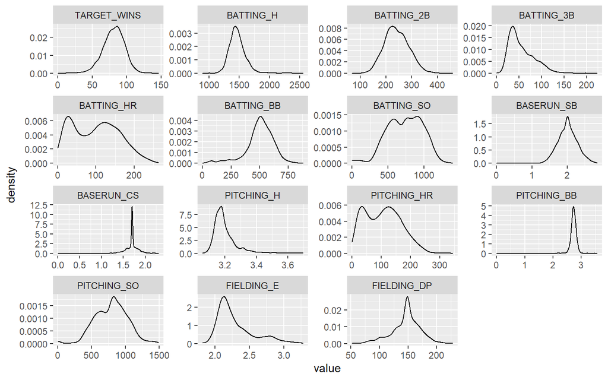

### Model 3 - BoxCox Transformation

In this model, we are going to apply a BoxCox transformation but also center and scale. This means that we want to subtract the mean of predictor’s data from predictor’s values while scale divides by the standard deviation. We were hoping this model to perform better but the resultant data skewness was not remediated as well as it was log transformation.

```
## [1] 259  14
```

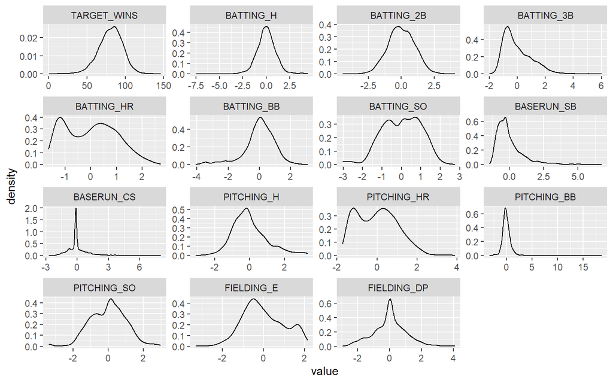

```
## TARGET_WINS   BATTING_H  BATTING_2B  BATTING_3B  BATTING_HR  BATTING_BB
## -0.39872320 -0.08517001 -0.01738229  1.10946519  0.18604214 -1.02575989
##  BATTING_SO  BASERUN_SB  BASERUN_CS  PITCHING_H PITCHING_HR PITCHING_BB
## -0.31260120  2.06582822  2.60217224  0.77405438  0.28778767  6.74389947
## PITCHING_SO  FIELDING_E FIELDING_DP
## -0.16007329  0.21740959  0.05371277
```

### Model 4 - kNN Imputation on missing values

*kNN Imputation*

As it may be unfamiliar to some, kNN is a method of building a model to impute data. While in theory a more sophisticated model could be used, kNN has some advantages in being simple and well understood.

```
##     TARGET_WINS       BATTING_H      BATTING_2B      BATTING_3B      BATTING_HR
##               0               0               0               0               0
##      BATTING_BB      BATTING_SO      BASERUN_SB      PITCHING_H     PITCHING_HR
##               0               0               0               0               0
##     PITCHING_BB     PITCHING_SO      FIELDING_E     FIELDING_DP  BATTING_SO_imp
##               0               0               0               0               0
##  BASERUN_SB_imp PITCHING_SO_imp FIELDING_DP_imp
##               0               0               0
```

[output not shown]

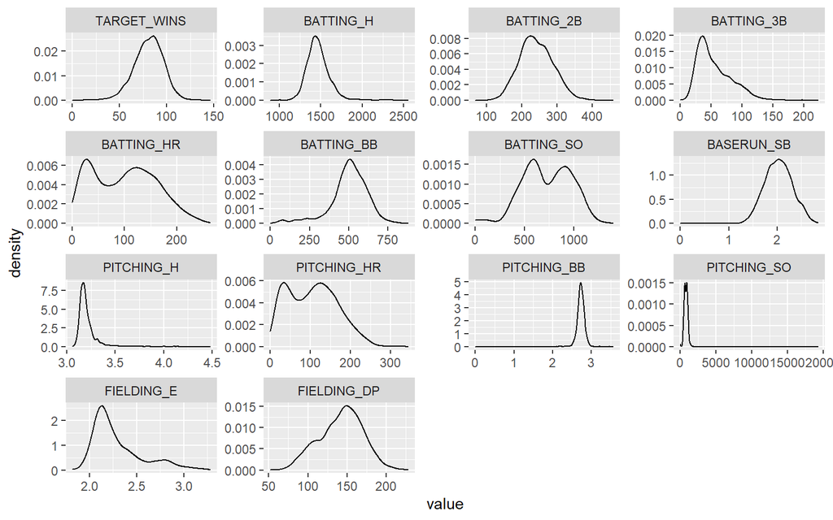

## Build Models

### Model 0 … a Sanity check

Using the imputed data we can simply run a linear regression against all the variables.

$$TARGET_WINS = 19.02 + BATTING_H(0.04) - BATTING_2B(0.02) + BATTING_3B(0.07) +$$
$$BATTING_HR(0.09) + BASERUN_SB(0.03) + PITCHING_H(0.01) + PITCHING_BB(0.01)$$
$$- FIELDING_E (0.03) - FIELDING_DP(0.11)$$

### Model 1 Basic Model

We select variable that seem correlated for this simple direct model.

Namely:

- Base Hits by Batters Batting_H
- Doubles by Batters Batting_2H
- Triples By Batters Batting_3B
- Home Runes Batting_HR
- Stolen Bases Baserun_SB
- Hits Allowed Pitching_H
- Walks Allowed Pitching_BB
- Errors in Fielding Fielding_E
- Double Plays Fielding_DP

All have a fairly direct impact on scoring or runs allowed.

### Model 3 BoxCox Transformation

For the BoxCox transformed data set we will continue with the same variables as previously.

### Model 4 kNN Imputation

Our model will be:
$$TARGET_WINS = 154.048 + BATTING_H (0.05) - BATTING_2B (0.04) + BATTING_3B (0.10) +$$
$$BATTING_BB (0.04) - BATTING_SO (0.02) + BASERUN_SB (12.89) - PITCHING_H (9.25) +$$
$$PITCHING_HR (0.08) - PITCHING_BB (9.83) + PITCHING_SO (0.00) - FIELDING_E (46.98) -$$
$$FIELDING_DP (0.14)$$

## Select Model

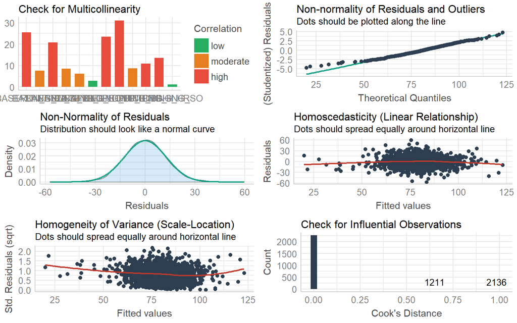

Data looks normally distributed but looks like there are high collinearity among some of the variables as shown below which might be affect their significance or coefficients in final model. According to Jim Frost, multicollinearity does not influence the predictions, precision and goodness of fit. He adds that if primary goal is to make predictions then you do not have to understand the role of each independent variable. There is some homoskedasticity in residuals as shown in graph 2 in second row.

```
## # Check for Multicollinearity
##
## Low Correlation
##
##    Parameter  VIF Increased SE
##   BATTING_SO 2.92         1.71
##  PITCHING_SO 1.11         1.05
##
## Moderate Correlation
##
##    Parameter  VIF Increased SE
##    BATTING_H 6.19         2.49
##   BATTING_2B 7.60         2.76
##   BATTING_BB 8.50         2.91
##  PITCHING_BB 8.76         2.96
##
## High Correlation
##
##    Parameter   VIF Increased SE
##   BATTING_3B 20.79         4.56
##   BASERUN_SB 25.46         5.05
##   PITCHING_H 10.87         3.30
##  PITCHING_HR 13.54         3.68
##   FIELDING_E 31.09         5.58
##  FIELDING_DP 23.43         4.84
```

```
## # Indices of model performance
##
## AIC      |      BIC |   R2 | R2 (adj.) |  RMSE | Sigma
## ------------------------------------------------------
## 18025.72 | 18105.94 | 0.36 |      0.35 | 12.61 | 12.65
```

It seems that model 4’s performance is almost consistent with other models in terms of collinearity and RMSE but adjusted r2 is comparatively better than others. The model, also makes intuitive sense. This suggests it should be selected. Now that we have selected model 4 as a best among the others, let’s move ahead and predict the target wins by predicting the test dataset on Model 4.

| TARGET_WINS | BATTING_H | BATTING_2B | BATTING_3B | BATTING_HR | BATTING_BB | BATTING_SO | BASERUN_SB | PITCHING_H | PITCHING_HR | PITCHING_BB | PITCHING_SO | FIELDING_E | FIELDING_DP | BATTING_SO_imp | BASERUN_SB_imp | PITCHING_SO_imp | FIELDING_DP_imp |
| --- | --- | --- | --- | --- | --- | --- | --- | --- | --- | --- | --- | --- | --- | --- | --- | --- | --- |
| 61 | 1209 | 170 | 33 | 83 | 447 | 1080 | 1.799341 | 3.082785 | 83 | 2.651278 | 1080 | 2.149219 | 156 | FALSE | FALSE | FALSE | FALSE |
| 64 | 1221 | 151 | 29 | 88 | 516 | 929 | 1.740363 | 3.087071 | 88 | 2.713490 | 929 | 2.133539 | 164 | FALSE | FALSE | FALSE | FALSE |
| 73 | 1395 | 183 | 29 | 93 | 509 | 816 | 1.778151 | 3.144885 | 93 | 2.707570 | 816 | 2.195900 | 153 | FALSE | FALSE | FALSE | FALSE |
| 87 | 1539 | 309 | 29 | 159 | 486 | 914 | 2.173186 | 3.187521 | 159 | 2.687529 | 914 | 2.096910 | 154 | FALSE | FALSE | FALSE | FALSE |
| 62 | 1445 | 203 | 68 | 5 | 95 | 416 | 2.190332 | 3.591399 | 14 | 2.411620 | 1123 | 2.790285 | 130 | FALSE | TRUE | FALSE | FALSE |
| 65 | 1431 | 236 | 53 | 10 | 215 | 377 | 2.202761 | 3.446226 | 20 | 2.624282 | 736 | 2.758155 | 105 | FALSE | TRUE | FALSE | FALSE |

## Appendix 1 R Code

Since all the data is for the same team, we will remove the word ‘TEAM’ from all variables for ease of reading.

```r
#Clean train dataset
name_list <- names(train)
name_list <- gsub("TEAM_", "", name_list)
names(train) <- name_list

#We do the same for the test dataset
name_list <- names(test)
name_list <- gsub("TEAM_", "", name_list)
names(test) <- name_list
```

Here is a preview of what the train dataset contains:

```r
head(train[1], 6)
```

```
## # A tibble: 6 x 1
##   TARGET_WINS
##         <dbl>
## 1          39
## 2          70
## 3          86
## 4          70
## 5          82
## 6          75
```

The train dataset has 2276 records with 16 variables.Let us look at the structure of the data.

```r
str(train)
```

```
## tibble [2,276 x 16] (S3: tbl_df/tbl/data.frame)
##  $ TARGET_WINS: num [1:2276] 39 70 86 70 82 75 80 85 86 76 ...
##  $ BATTING_H  : num [1:2276] 1445 1339 1377 1387 1297 ...
##  $ BATTING_2B : num [1:2276] 194 219 232 209 186 200 179 171 197 213 ...
##  $ BATTING_3B : num [1:2276] 39 22 35 38 27 36 54 37 40 18 ...
##  $ BATTING_HR : num [1:2276] 13 190 137 96 102 92 122 115 114 96 ...
##  $ BATTING_BB : num [1:2276] 143 685 602 451 472 443 525 456 447 441 ...
##  $ BATTING_SO : num [1:2276] 842 1075 917 922 920 ...
##  $ BASERUN_SB : num [1:2276] NA 37 46 43 49 107 80 40 69 72 ...
##  $ BASERUN_CS : num [1:2276] NA 28 27 30 39 59 54 36 27 34 ...
##  $ BATTING_HBP: num [1:2276] NA NA NA NA NA NA NA NA NA NA ...
##  $ PITCHING_H : num [1:2276] 9364 1347 1377 1396 1297 ...
##  $ PITCHING_HR: num [1:2276] 84 191 137 97 102 92 122 116 114 96 ...
##  $ PITCHING_BB: num [1:2276] 927 689 602 454 472 443 525 459 447 441 ...
##  $ PITCHING_SO: num [1:2276] 5456 1082 917 928 920 ...
##  $ FIELDING_E : num [1:2276] 1011 193 175 164 138 ...
##  $ FIELDING_DP: num [1:2276] NA 155 153 156 168 149 186 136 169 159 ...
```

We can see that all of the variables are integers, and BATTING_HBP has a lot of missing values.We will look at the summary of the data to find some idea about the distributions.

```r
summary(train)
```

```
##   TARGET_WINS       BATTING_H      BATTING_2B      BATTING_3B
##  Min.   :  0.00   Min.   : 891   Min.   : 69.0   Min.   :  0.00
##  1st Qu.: 71.00   1st Qu.:1383   1st Qu.:208.0   1st Qu.: 34.00
##  Median : 82.00   Median :1454   Median :238.0   Median : 47.00
##  Mean   : 80.79   Mean   :1469   Mean   :241.2   Mean   : 55.25
##  3rd Qu.: 92.00   3rd Qu.:1537   3rd Qu.:273.0   3rd Qu.: 72.00
##  Max.   :146.00   Max.   :2554   Max.   :458.0   Max.   :223.00
##
##    BATTING_HR       BATTING_BB      BATTING_SO       BASERUN_SB
##  Min.   :  0.00   Min.   :  0.0   Min.   :   0.0   Min.   :  0.0
##  1st Qu.: 42.00   1st Qu.:451.0   1st Qu.: 548.0   1st Qu.: 66.0
##  Median :102.00   Median :512.0   Median : 750.0   Median :101.0
##  Mean   : 99.61   Mean   :501.6   Mean   : 735.6   Mean   :124.8
##  3rd Qu.:147.00   3rd Qu.:580.0   3rd Qu.: 930.0   3rd Qu.:156.0
##  Max.   :264.00   Max.   :878.0   Max.   :1399.0   Max.   :697.0
##                                   NA's   :102      NA's   :131
##    BASERUN_CS     BATTING_HBP      PITCHING_H     PITCHING_HR
##  Min.   :  0.0   Min.   :29.00   Min.   : 1137   Min.   :  0.0
##  1st Qu.: 38.0   1st Qu.:50.50   1st Qu.: 1419   1st Qu.: 50.0
##  Median : 49.0   Median :58.00   Median : 1518   Median :107.0
##  Mean   : 52.8   Mean   :59.36   Mean   : 1779   Mean   :105.7
##  3rd Qu.: 62.0   3rd Qu.:67.00   3rd Qu.: 1682   3rd Qu.:150.0
##  Max.   :201.0   Max.   :95.00   Max.   :30132   Max.   :343.0
##  NA's   :772     NA's   :2085
##   PITCHING_BB      PITCHING_SO        FIELDING_E      FIELDING_DP
##  Min.   :   0.0   Min.   :    0.0   Min.   :  65.0   Min.   : 52.0
##  1st Qu.: 476.0   1st Qu.:  615.0   1st Qu.: 127.0   1st Qu.:131.0
##  Median : 536.5   Median :  813.5   Median : 159.0   Median :149.0
##  Mean   : 553.0   Mean   :  817.7   Mean   : 246.5   Mean   :146.4
##  3rd Qu.: 611.0   3rd Qu.:  968.0   3rd Qu.: 249.2   3rd Qu.:164.0
##  Max.   :3645.0   Max.   :19278.0   Max.   :1898.0   Max.   :228.0
##                   NA's   :102                        NA's   :286
```

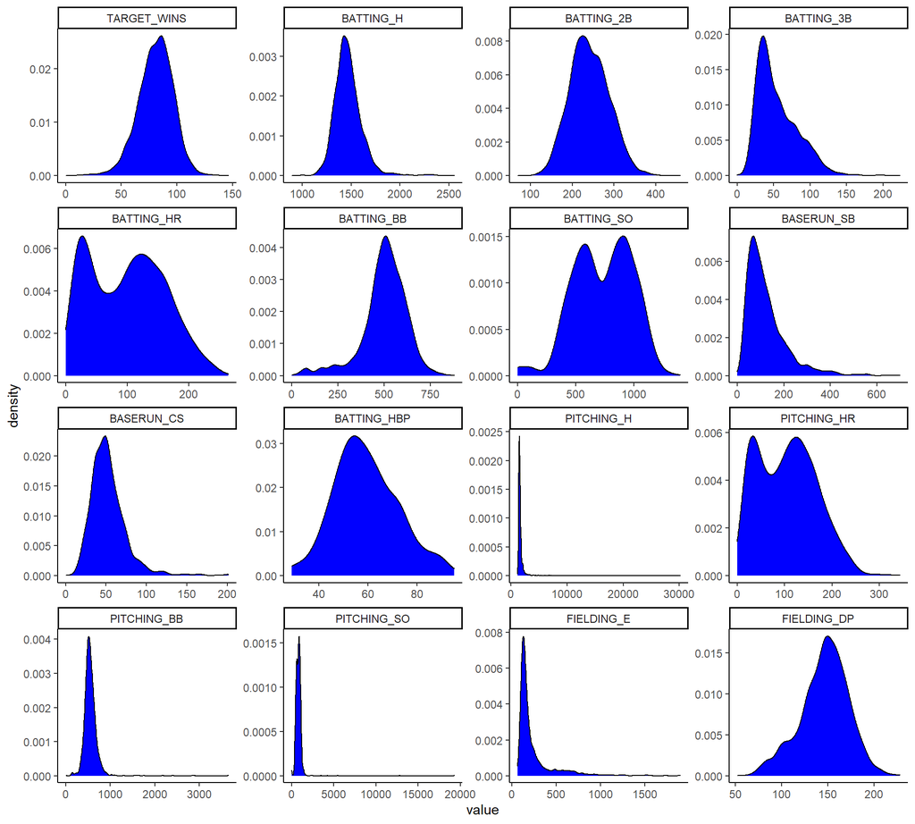

```r
m = melt(train)
ggplot(m, aes(x= value)) +
   geom_density(fill='blue') +
   facet_wrap(~variable, scales = 'free') +
   theme_classic()
```

We can see that 12 of the variables have a significant skew. only 4 of the 16 variables are normally or close to normally distributed. The response variable Target_wins seems to be normally distributed.Batting_Hr, Batting_SO and Pitching_HR are bi-modal.

10 of the 16 variables have a minimum value of 0. This is not a major concern as the total % of 0 in each column is less than 1%.

```r
train %>%
  gather(variable, value) %>%
  filter(value == 0) %>%
  group_by(variable) %>%
  tally() %>%
  mutate(percent = n / nrow(train) * 100) %>%
  arrange(desc(n)) %>%
  rename(`Variable With Zeros` = variable,
         `Number of Records` = n,
         `Share of Total` = percent) %>%
  kable() %>%
  kable_styling()
```

[output not shown]

6 of the variables have above 4% missing values:

• BATTING_SO: 102 (4.5% of total)

• PITCHING_SO: 102 (4.5% of total)

• BASERUN_SB: 131 (5.8% of total)

• BASERUN_CS: 772 (34% of total, needs to be looked at closely, impute or exclude?)

• BATTING_HBP: 2085 (92% of total, exclude from analysis?)

• FIELDING_DP: 286 (12.6% of total,needs to be looked at closely, impute or exclude?)

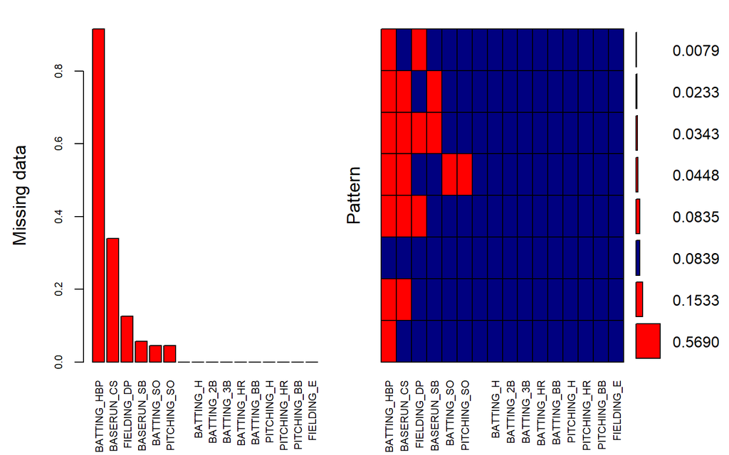

```
##
##  Variables sorted by number of missings:
##     Variable      Count
##  BATTING_HBP 0.91608084
##   BASERUN_CS 0.33919156
##  FIELDING_DP 0.12565905
##   BASERUN_SB 0.05755712
##   BATTING_SO 0.04481547
##  PITCHING_SO 0.04481547
##  TARGET_WINS 0.00000000
##    BATTING_H 0.00000000
##   BATTING_2B 0.00000000
##   BATTING_3B 0.00000000
##   BATTING_HR 0.00000000
##   BATTING_BB 0.00000000
##   PITCHING_H 0.00000000
##  PITCHING_HR 0.00000000
##  PITCHING_BB 0.00000000
##   FIELDING_E 0.00000000
```

```r
#Plot missing values using library VIM
mice_plot <- aggr(train, col=c('navyblue','red'),numbers=TRUE, sortVars=TRUE,labels=names(train), cex.axis=.7,gap=3, ylab=c("Missing data","Pattern"))
```

```r
#Test for complete rows
print('Percentage of complete case is')
```

```
## [1] "Percentage of complete case is"
```

```r
print((sum(complete.cases(train))/nrow(train))*100)
```

```
## [1] 8.391916
```

**Outliers**

```r
ggplot(stack(train[,-1]), aes(x = ind, y = values, fill=ind)) +
  geom_boxplot(outlier.colour = "red",  outlier.alpha=.4) +
  coord_cartesian(ylim = c(0, 1000)) +
  theme_classic()+
  theme(axis.text.x=element_text(angle=45, hjust=1))
```

The variables Batting_BB, Batting_CS, Baserun_SB, Pitching_BB and Fielding_E have a significant number of outliers.

**Correlations among predictors**

```r
train %>%
  cor(., use = "complete.obs") %>%
  corrplot(., method = "color", type = "upper", tl.col = "black", tl.cex=.8, diag = FALSE)
```

There are positive or negative correlations among the predictors. A small number of values are not correlated. Let us look at the numerical correlations with the response variable. We see that the predictors Batting_H, Batting_HR, Batting_BB, Pitching_H, and Pitching_HR are more correlated and should be included in our regression.

```r
correlation <- train %>%
  cor(., use = "complete.obs") %>%
  as.data.frame() %>%
  rownames_to_column()%>%
  gather(Variable, Correlation, -rowname)

correlation %>%
  filter(Variable == "TARGET_WINS") %>%
     arrange(desc(Correlation)) %>%
  kable() %>%
  kable_styling()
```

Let us look at significant correlations among the independent variables. We see that four of the pairs have a correlation close to 1. This can lead to autocorrelation errors in our analysis.

```r
correlation %>%
  filter(abs(Correlation) > .5 & Correlation!=1 ) %>%
  distinct(Correlation, .keep_all = T)%>%
  kable() %>%
  kable_styling()
```

*Data Preparation*

First we will remove Batting_HBP (Hit by Pitch) which has 92% missing values.

```r
train <- train[-10]
```

```r
par(mfrow=c(1,2))
gg_miss_upset(train,
              nsets = 5,
              nintersects = NA)
gg_miss_case(train)+
  theme_classic()
```

```r
train<-train%>%
   mutate(rowsum=rowSums(is.na(train)))%>%
   filter(rowsum<5)%>%
   select(-rowsum)
```

In deciding whether data is MCAR or MAR, one approach is to explore patterns of missingness between variables. This is particularly important for a primary outcome measure/dependent variable. We will test the two cases with most missing values.

The wins for players who’s Baserun_cs data is known is the blue box plot, and the wins with missing Baserun_cs data is the gray box plot.We do not see a lot of difference in the mean, but the Interquartile range has changed. Also the mean changes significantly between Fielding_DP and Baserun_cs if we do not include missing data.

```r
library(finalfit)
explanatory <- c('BASERUN_CS','FIELDING_DP' )
dependent <- 'TARGET_WINS'
train %>%
  missing_pairs(dependent, explanatory)
```

102 of the observations have 3 of the variables missing.The highest case missing is in the BASERUN_CS variable, so this deserves an analysis of its own.We find a highly positively skewed distribution with most missing data after the 125 on the x axis. We want to make sure that the shape of our distribution does not change as we impute the data.

```r
train %>%
  ggplot(aes(BASERUN_CS)) +
  geom_histogram(bins = 50) +
  geom_vline(aes(xintercept = mean(BASERUN_CS, na.rm = T)), col = "red", lty = 2) +
  geom_vline(aes(xintercept = median(BASERUN_CS, na.rm = T)),col = "green", lty = 2) +
  labs(x = element_blank(),
       y = "Count",
       title = "Distribution of Caught Stealing Bases",
       caption = "* Red line is the mean value and green is the median")
```

*Modeling*

*Model 1 - Basic Model*

```r
# Replacing extreme values with median for training & evaluation datasets and removing BATTING_HBP which has 92% missing values
train2 <- train %>% mutate(PITCHING_H = if_else(PITCHING_H > 5000, median(PITCHING_H), PITCHING_H),
                            PITCHING_SO = if_else(PITCHING_SO > 1500, median(PITCHING_SO), PITCHING_SO)) %>%
  select(-BATTING_HBP)

test2 <- test %>% mutate(PITCHING_H = if_else(PITCHING_H > 5000, median(PITCHING_H), PITCHING_H),
                            PITCHING_SO = if_else(PITCHING_SO > 1500, median(PITCHING_SO), PITCHING_SO)) %>%
  select(-BATTING_HBP)
```

```r
# Replacing missing values with median
train2[] <- lapply(train2, function(x) ifelse(is.na(x), median(x, na.rm=TRUE), x))
test2[] <- lapply(test2, function(x) ifelse(is.na(x), median(x, na.rm=TRUE), x))


# Verifying for missing values
#sapply(train2, function(x) sum(is.na(x)))
#vis_miss(train2) # From naniar library

# Checking skewness
#sapply(train2, function(x) skewness(x))
```

*Model 2 - Log Transformation*

```r
train_log <- train2 # Model 2
test_log <- test2

# Applying log transformation for highly skewed variables
#training
train_log$PITCHING_BB <- log10(train_log$PITCHING_BB + 1)
train_log$PITCHING_H <- log10(train_log$PITCHING_H + 1)
train_log$FIELDING_E <- log10(train_log$FIELDING_E + 1)
train_log$BASERUN_SB <- log10(train_log$BASERUN_SB + 1)
train_log$BASERUN_CS <- log10(train_log$BASERUN_CS + 1)
#test
test_log$PITCHING_BB <- log10(test_log$PITCHING_BB + 1)
test_log$PITCHING_H <- log10(test_log$PITCHING_H + 1)
test_log$FIELDING_E <- log10(test_log$FIELDING_E + 1)
test_log$BASERUN_SB <- log10(test_log$BASERUN_SB + 1)
test_log$BASERUN_CS <- log10(test_log$BASERUN_CS + 1)


# CHecking skewness
sapply(train_log, function(x) skewness(x))

# Printing summary statistics
#summary(train_log)

# Skewness
ggplot(melt(train_log), aes(x=value))+geom_density()+facet_wrap(~variable, scales='free')
```

*Model 3 - BoxCox Transformation*

```r
# Converting tibble to df
train_data_bx <- data.frame(train2)
test_data_bx <- data.frame(test2)

dim(test2)
# PreProcess function for boxcox transformation
preproc_value <- preProcess(train_data_bx[,-1], c("BoxCox", "center", "scale"))

# Transformation
train_bx_transformed <- predict(preproc_value, train_data_bx)
test_bx_transformed <- predict(preproc_value, test_data_bx)

# Normality and skewness
ggplot(melt(train_bx_transformed), aes(x=value))+geom_density()+facet_wrap(~variable, scales='free')
sapply(train_bx_transformed, function(x) skewness(x))
```

*Model 4 - kNN Imputation on missing values*

*kNN Imputation*

```r
set.seed(1100)
library(VIM)

# knn imputation for missing values
# training
train_data_knn <- train %>% # TRAINING
  select(-BATTING_HBP, -BASERUN_CS)
train_knn <- kNN(train_data_knn, variable = c("BATTING_SO", "BASERUN_SB", "PITCHING_SO","FIELDING_DP"),k=6)

#test
test_data_knn <- test %>% # TEST
  select(-BATTING_HBP, -BASERUN_CS)
test_knn <- kNN(test_data_knn, variable = c("BATTING_SO", "BASERUN_SB", "PITCHING_SO","FIELDING_DP"),k=6)

# CHecking for missing values
colSums(is.na(train_knn))

# Log transformation on knn imputed dataset
train_knn_log <- train_data_knn # Model 2
test_knn_log <- test_data_knn
#test_log <- test2

# Applying log transformation for highly skewed variables
#training
train_knn_log$PITCHING_BB <- log10(train_knn_log$PITCHING_BB + 1)
train_knn_log$PITCHING_H <- log10(train_knn_log$PITCHING_H + 1)
train_knn_log$FIELDING_E <- log10(train_knn_log$FIELDING_E + 1)
train_knn_log$BASERUN_SB <- log10(train_knn_log$BASERUN_SB + 1)

# TEST DATASET TRANSFORMATION
test_knn_log$PITCHING_BB <- log10(test_knn_log$PITCHING_BB + 1)
test_knn_log$PITCHING_H <- log10(test_knn_log$PITCHING_H + 1)
test_knn_log$FIELDING_E <- log10(test_knn_log$FIELDING_E + 1)
test_knn_log$BASERUN_SB <- log10(test_knn_log$BASERUN_SB + 1)

# CHecking skewness and normality
sapply(train_knn_log, function(x) skewness(x))
ggplot(melt(train_knn_log), aes(x=value))+geom_density()+facet_wrap(~variable, scales='free')
```

## References

https://easystats.github.io/performance/

https://statisticsbyjim.com/regression/multicollinearity-in-regression-analysis/#:~:text=Multicollinearity%20makes%20it%20hard%20to,a%20way%20to%20fix%20multicollinearity

Marker: 621-01_p